# SEAMLESS DASHBOARDING WITH SHINY + FLEXDASHBOARD

Tosin Dairo

DEC 1, 2019

[figure not shown]

LAGOS RUG LOGO

[figure not shown]

## What is LAG-RUG-DASH

LAG-RUG-DASH uses Flexdashboard and Shiny, which allow for rapid web application development as dashboard by capitalising on the usage of R-markdowns. This helps to attain the final stage of the Data Science workflow or pipeline which is communication of analysed data.

## Dependecies

- rmarkdown
- httr
- scales
- flexdashboard
- shiny
- DT
- plotly
- naniar
- devtools

## Getting Started

To install LAG-RUG-DASH from source you need Rstudio and R lang 3.4.4> in order to get started. Run the following in command prompt

```
git clone https://github.com/tosi-n/LAG-RUG-DASH.git
cd LAG-RUG-DASH
then open the project folder LAG-RUG-DASH from Rstudio
```

### File Paths

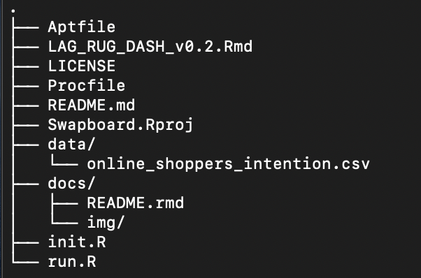

Directory

### Alternatively

To install LAG-RUG-DASH from google drive link, after download Rstudio and R lang 3.4.4>. Download all from link below

```
https://drive.google.com/drive/folders/1jOiaKovigCXNB16HI5v9SJQIkwBm-bR4?usp=sharing

then open the project folder LAG-RUG-DASH from Rstudio
```

### Install Dependencies

In Rstudio, install package dependencies using the init.r file. Open init.r and click run to install deependencies on Rstudio.

[figure not shown]

### Design and Layout

Layout operates in 4 TIERS based on client or user requirements

- Sidebar layout (Input {.sidebar}) SB
- Tab layout T(Tab-name)(======) T
- Rows and Columns (Row{}) R
- Widgets / Components C

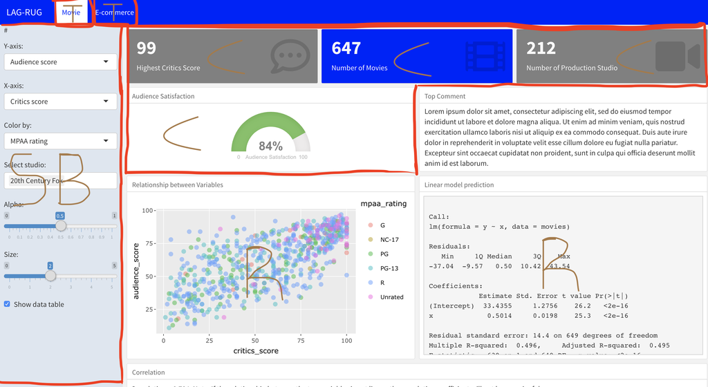

Edit code in LAG_RUG_DASH_v0.2.Rmd to fit your requirement.

Note: sidebar is used for creating dashboard input data or feature to be implemented on the entire dashboard.

## Hosting on Heroku

In order to have our LAG-RUG-DASH Livee on heroku, follow the below listed requirements and process.

> init.R

> Procfile

> Aptfile

> run.R

> heroku-buildpack-r

As indicated earlier, the init.R file contains packages to be installed on heroku server. Heroku dynos uses a contanerized feature to host application. For heroku dynos to know the kind of application we are install we need to set Procfile as web feature so that heroku know our application is a web application. Procfile also carries information about the file root directory and the console type to use.

```
web: env fakechroot fakeroot chroot /app/.root /bin/sh -c 'cd /app && /usr/bin/R -f /app/run.R --gui-none --no-save'
```

As seen above the Procfile requires a set of Linux console environment in order for it to operate. Using the Aptfile, we tell heroku to install the below listed Linux console in order for heroku to run R and dashboard packages in the server.

```
libpq-dev
libxml2-dev
gsl-bin
libgsl0-dev
```

With the above done, R shiny is the runtime set for the dashboard to operate on so therefore, a run.R file is needed for the dashboard rendering. The run.R file is used to:

- Set port for heroku to listen to
- Set the default working directory
- Run the dashboard on the server heroku creates

```
port <- Sys.getenv('PORT')

setwd('/app')

rmarkdown::run(
  'LAG_RUG_DASH_v0.2.Rmd'
  , shiny_args = list(
    host = '0.0.0.0',
    port = as.numeric(port)
  )
)
```

### git push Heroku Deploy

> Create heroku account, then go to heroku dashboard and create application by clicking on New. Set application name and set server location as US or Europe then create.

After creating a heroku account and application, go to Rstudio terminal run the following commands:

```
heroku login

git init

git add .

git commit -m "commit message"

heroku git:remote -a app-name

heroku buildpacks:add http://github.com/virtualstaticvoid/heroku-buildpack-r.git#heroku-16

heroku stack:set heroku-16

git push heroku master
```

Check deployment success using command in Rstudio terminal:

```
heroku logs --tail
```

### Update Deployed Dashboard

For constant update to dashboard on a live heroku server, go to Rstudio terminal run the following commands:

```
heroku login

git add .

git commit -m "commit message"

heroku git:remote -a app-name

git push heroku master
```

## Materials

- [Presentation Slides](https://docs.google.com/presentation/d/16dy_5JV0SqDYkyzJLO1wCxfztkOFYziuYx_kpEnALY8/edit#slide=id.g6bb4db640a_0_63)
- [Documentation on using Flexdashboard](https://rmarkdown.rstudio.com/flexdashboard/using.html)
- [Shiny and Flexdashboard](https://rmarkdown.rstudio.com/flexdashboard/shiny.html)